# Human Activity Prediction

Jie Cao

12/12/2020

## Overview

Using devices such as Jawbone Up, Nike FuelBand, and Fitbit it is now possible to collect a large amount of data about personal activity relatively inexpensively. These type of devices are part of the quantified self movement – a group of enthusiasts who take measurements about themselves regularly to improve their health, to find patterns in their behavior, or because they are tech geeks. One thing that people regularly do is quantify how much of a particular activity they do, but they rarely quantify how well they do it.

In this project, I will use data from accelerometers on the belt, forearm, arm, and dumbell of 6 participants. They were asked to perform barbell lifts correctly and incorrectly in 5 different ways. We will build a machine learning model to predict the activity they performed.

More information about the Weight Lifting Exercise Dataset is available from the [website](http://groupware.les.inf.puc-rio.br/har).

## Libraries

```r
library(caret)
library(rattle)
```

## Data Loading

```r
# Download the data
trainURL <- "https://d396qusza40orc.cloudfront.net/predmachlearn/pml-training.csv"
testURL <- "https://d396qusza40orc.cloudfront.net/predmachlearn/pml-testing.csv"
trainFile <- "./data/pml-training.csv"
testFile  <- "./data/pml-testing.csv"
if (!file.exists("./data")) {
  dir.create("./data")
}
if (!file.exists(trainFile)) {
  download.file(trainURL, destfile=trainFile, method="curl")
}
if (!file.exists(testFile)) {
  download.file(testURL, destfile=testFile, method="curl")
}
# Load data
trainRaw <- read.csv("./data/pml-training.csv")
testRaw <- read.csv("./data/pml-testing.csv")

# Explore data
dim(trainRaw)
```

```
## [1] 19622   160
```

```r
dim(testRaw)
```

```
## [1]  20 160
```

The training data has 19622 observations, and the testing data has 20 observations. They each has 160 variables.

## Data Processing

```r
str(trainRaw)
```

```
## 'data.frame':    19622 obs. of  160 variables:
##  $ X                       : int  1 2 3 4 5 6 7 8 9 10 ...
##  $ user_name               : Factor w/ 6 levels "adelmo","carlitos",..: 2 2 2 2 2 2 2 2 2 2 ...
##  $ raw_timestamp_part_1    : int  1323084231 1323084231 1323084231 1323084232 1323084232 1323084232 1323084232 1323084232 1323084232 1323084232 ...
##  $ raw_timestamp_part_2    : int  788290 808298 820366 120339 196328 304277 368296 440390 484323 484434 ...
##  $ cvtd_timestamp          : Factor w/ 20 levels "02/12/2011 13:32",..: 9 9 9 9 9 9 9 9 9 9 ...
##  $ new_window              : Factor w/ 2 levels "no","yes": 1 1 1 1 1 1 1 1 1 1 ...
##  $ num_window              : int  11 11 11 12 12 12 12 12 12 12 ...
##  $ roll_belt               : num  1.41 1.41 1.42 1.48 1.48 1.45 1.42 1.42 1.43 1.45 ...
##  $ pitch_belt              : num  8.07 8.07 8.07 8.05 8.07 8.06 8.09 8.13 8.16 8.17 ...
##  $ yaw_belt                : num  -94.4 -94.4 -94.4 -94.4 -94.4 -94.4 -94.4 -94.4 -94.4 -94.4 ...
##  $ total_accel_belt        : int  3 3 3 3 3 3 3 3 3 3 ...
##  $ kurtosis_roll_belt      : Factor w/ 397 levels "","-0.016850",..: 1 1 1 1 1 1 1 1 1 1 ...
##  $ kurtosis_picth_belt     : Factor w/ 317 levels "","-0.021887",..: 1 1 1 1 1 1 1 1 1 1 ...
##  $ kurtosis_yaw_belt       : Factor w/ 2 levels "","#DIV/0!": 1 1 1 1 1 1 1 1 1 1 ...
```

[output cut: 86 more lines]

We notice that some variables contain NA values. We remove them from the dataset.

```r
trainData <- trainRaw[, colSums(is.na(trainRaw)) == 0]
testData <- testRaw[, colSums(is.na(testRaw)) == 0]
dim(trainData)
```

```
## [1] 19622    93
```

```r
dim(testData)
```

```
## [1] 20 60
```

There are also some variables we suspect providing very few information in prediction - first 7 columns (participant IDs, timestamps and windows).

```r
trainData <- trainData[, -c(1:7)]
testData <- testData[, -c(1:7)]
dim(trainData)
```

```
## [1] 19622    86
```

```r
dim(testData)
```

```
## [1] 20 53
```

Now we keep variables that exist in both training and testing, and check if there’s remaining variables of near zero variance.

```r
trainVars <- names(trainData)
testVars <- names(testData)
bothVars <- intersect(trainVars, testVars)

trainData <- trainData[, c(bothVars, "classe")]
testData <- testData[, bothVars]

NZV <- nearZeroVar(trainData)
length(NZV)
```

```
## [1] 0
```

```r
dim(trainData)
```

```
## [1] 19622    53
```

```r
dim(testData)
```

```
## [1] 20 52
```

After cleaning, the training data has 53 variables (52 potential predictors and 1 label) and the testing data has 52 variables (52 potential predictors).

## Modeling

We will fit three different models in this section. They are **classification tree**, **random forest** and **gradient boosting machine**.

### Data split

In order to evaluate models, we further split the cleaned training data into training and validation sets.

```r
set.seed(1)
inTrain <- createDataPartition(trainData$classe, p = 0.70, list = FALSE)
train <- trainData[inTrain, ]
validation <- trainData[-inTrain, ]
```

### Classification tree

To choose the best model and avoid overfitting, we use 5-fold cross-validation to find the best classification tree model.

[figure not shown]

```r
model_ct <- train(classe ~ ., data = train, method = "rpart",
                  trControl = trainControl(method = "cv", number = 5))
fancyRpartPlot(model_ct$finalModel)
```

```r
val_ct <- predict(model_ct, newdata = validation)
conf_mat_ct <- confusionMatrix(validation$classe, val_ct)
conf_mat_ct$table
```

```
##           Reference
## Prediction    A    B    C    D    E
##          A 1523   23  124    0    4
##          B  498  350  291    0    0
##          C  489   30  507    0    0
##          D  412  169  383    0    0
##          E  174  139  280    0  489
```

```r
conf_mat_ct$overall[1]
```

```
##  Accuracy
## 0.4875106
```

The selected classification tree only achieve an accuracy of 0.49 in the validation set.

### Random forest

```r
model_rf <- train(classe ~ ., data = train, method = "rf",
                  trControl = trainControl(method = "cv", number = 5),
                  verbose = FALSE)
model_rf
```

```
## Random Forest
##
## 13737 samples
##    52 predictor
##     5 classes: 'A', 'B', 'C', 'D', 'E'
##
## No pre-processing
## Resampling: Cross-Validated (5 fold)
## Summary of sample sizes: 10990, 10990, 10990, 10988, 10990
## Resampling results across tuning parameters:
##
##   mtry  Accuracy   Kappa
##    2    0.9900266  0.9873821
##   27    0.9903906  0.9878431
##   52    0.9824551  0.9778012
##
## Accuracy was used to select the optimal model using the largest value.
## The final value used for the model was mtry = 27.
```

The best random forest model selected by the cross-validation uses 27 variable at each split. Below we show the variable importance in the model. We notice that `roll_belt`, `pitch_forarm`, `yaw_belt`, `magnet_dumbell_y` and `pitch_belt` are the top 5 important variables in this model.

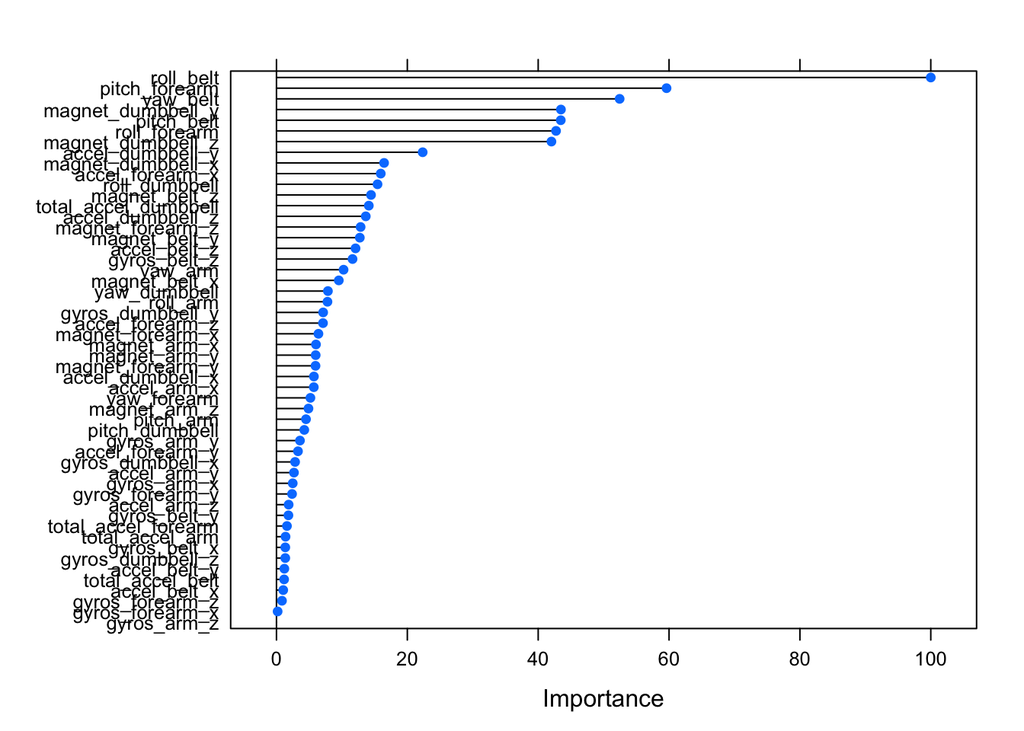

```r
plot(varImp(model_rf))
```

```r
val_rf <- predict(model_rf, newdata = validation)
conf_mat_rf <- confusionMatrix(validation$classe, val_rf)
conf_mat_rf$table
```

```
##           Reference
## Prediction    A    B    C    D    E
##          A 1672    1    1    0    0
##          B    3 1135    0    1    0
##          C    0   13 1005    8    0
##          D    0    0   14  949    1
##          E    1    1    0    3 1077
```

```r
conf_mat_rf$overall[1]
```

```
##  Accuracy
## 0.9920136
```

The selected random forest model can achieve an accuracy of 0.99 in the validation set.

### Gradient boosting machine

```r
model_gbm <- train(classe ~ ., data = train, method = "gbm",
                   trControl = trainControl(method = "cv", number = 5),
                   verbose = FALSE)
model_gbm
```

```
## Stochastic Gradient Boosting
##
## 13737 samples
##    52 predictor
##     5 classes: 'A', 'B', 'C', 'D', 'E'
##
## No pre-processing
## Resampling: Cross-Validated (5 fold)
## Summary of sample sizes: 10989, 10989, 10990, 10991, 10989
## Resampling results across tuning parameters:
##
##   interaction.depth  n.trees  Accuracy   Kappa
##   1                   50      0.7565002  0.6914904
##   1                  100      0.8223063  0.7751360
##   1                  150      0.8536815  0.8148623
##   2                   50      0.8576851  0.8197324
##   2                  100      0.9099516  0.8860547
##   2                  150      0.9314997  0.9133197
##   3                   50      0.8999071  0.8733026
##   3                  100      0.9446021  0.9299010
##   3                  150      0.9607626  0.9503593
##
## Tuning parameter 'shrinkage' was held constant at a value of 0.1
##
## Tuning parameter 'n.minobsinnode' was held constant at a value of 10
## Accuracy was used to select the optimal model using the largest value.
## The final values used for the model were n.trees = 150, interaction.depth =
##  3, shrinkage = 0.1 and n.minobsinnode = 10.
```

The final model selected by the cross-validation uses 150 trees, depth of 3 for each tree, shrinkage of 0.1 and minimum obervations in each node of 10.

```r
val_gbm <- predict(model_gbm, newdata = validation)
conf_mat_gbm <- confusionMatrix(validation$classe, val_gbm)
conf_mat_gbm$table
```

```
##           Reference
## Prediction    A    B    C    D    E
##          A 1645   17   11    0    1
##          B   33 1077   27    1    1
##          C    0   35  965   20    6
##          D    0    4   33  918    9
##          E    1   14    7   19 1041
```

```r
conf_mat_gbm$overall[1]
```

```
##  Accuracy
## 0.9593883
```

## Prediction

Based on the results we obtained above, the random forest model is the best one in terms of validation accuracy. Hence, we use the random forest model to make prediction on the test dataset.

```r
test_rf <- predict(model_rf, newdata = testData)
test_rf
```

```
##  [1] B A B A A E D B A A B C B A E E A B B B
## Levels: A B C D E
```